# Hw 21

```r
Chi_Square_Normal_Test <- function(x, n) {
   break_p <- vector("double", length = n + 1)
   x_mean <- mean(x)
   x_stdev <- sqrt(var(x))
   break_p[1] <- min(x) - 1
   size <- length(x)
   for(j in 2:n) {
      break_p[j] <- qnorm((j-1)/n, mean = x_mean,
      sd = x_stdev, lower.tail = TRUE, log.p = FALSE)
      }
   break_p[n+1] <- max(x) + 1
   p_x <- hist(x, breaks = break_p, plot = FALSE)
   x_Counts <- p_x$counts
   Norm_counts <- vector("double", length = n)
   for(j in 1:n) {
      Norm_counts[j] <- size * 1/n
      }
   p_SE <- hist(x, breaks = break_p, main="Histogram of
   Standardized Errors")
   normal_fit <- chisq.test(x_Counts, p = Norm_counts,
   rescale.p = TRUE)
   Chitest_value <- pchisq(normal_fit$statistic, df = n - 3,
   lower.tail=FALSE)
   return(Chitest_value)
}
```

```r
standarized_errors_MR <- function(y, x) {
   n <- length(y)
   k <- ncol(x)
   x1 <- vector("double", length = n)
   for(j in 1:n) {
      x1[j] <- 1
      }
   Matrix_X <- cbind(x1, x)
   Matrix_Y <- cbind(y)
   Matrix_H <- Matrix_X%*%solve(t(Matrix_X)%*%Matrix_X)%*%t(Matrix_X)
   Matrix_YP <- Matrix_H%*%Matrix_Y
   y_p <- Matrix_YP[,1]
   h <- vector("double", length = n)
   D <- vector("double", length = n)
   Error <- vector("double", length = n)
   Standard_E <- vector("double", length = n)
   se <- sqrt(sum((y - y_p)^2)/(n - k - 1))
   for(i in 1:n) {
      h[i] <- Matrix_H[i,i]
      Error[i] <- y[i] - y_p[i]
      Standard_E[i] <- Error[i] / (se * sqrt(1 - h[i]))
      D[i] <- (y[i] - y_p[i])^2 * h[i] / ((k - 1) * se^2 * (1 - h[i])^2)
      }
    SEhD <- cbind(Standard_E,h,D)
   return(SEhD)}
```

```r
Durbin_Watson_Test <- function(x) {

    x_square_sum <- sum(x*x)
    size <- length(x)
    x_d <- vector("double", length = size)
    x_d[1] = 0
    for(j in 2:size) {
    x_d[j] <- x[j] - x[j - 1]
    }
    d <- sum(x_d*x_d) / x_square_sum
    return(d)
}
```

```r
Hetero_plot <- function(y,x,l)
{
  n <- length(y)
  linearModelVar <- lm(y ~ x)
  a <- coef(linearModelVar)[1]
  b = vector("numeric",l)
  for(i in 1:l)
  {
    b[i] <- coef(linearModelVar)[i+1]
  }
  Price_p <- vector("double", length = n)
  for(i in 1:n) {
    temp = a
    for(j in 1:l)
      temp = temp + b[j]*x[i,j]
    Price_p[i] <- temp
  }
  Standard_E <- standarized_errors_MR(y,x)[,1]
  plot(x = Price_p,y = Standard_E,  xlab = "Predicted Price",  ylab = "Standardized Error",  xlim = c(min(Price_p)-0.1,max(Price_p)+0.1),  ylim = c(-3,3), main = "y vs Error")

}
```

```r
Run_Test <- function(x) {
    size <- length(x)
  Run_Count <- vector("double", length = size)
  x_median <- median(x)
    x_cat <- x > x_median
    print(x_cat)
    Run_Count[1] <- 1
    for(j in 2:n) {
    if (x_cat[j] == x_cat[j-1]) {
      Run_Count[j] <- Run_Count[j-1]
  } else {
      Run_Count[j] <- Run_Count[j-1] + 1
          }
    }
    n1 <- sum(x_cat == 'TRUE')
    n2 <- sum(x_cat == 'FALSE')
    Run_Mean <- 2*n1*n2/(n1+n2) + 1
    Run_S <- sqrt(2*n1*n2*(2*n1*n2-n1-n2)/(n1+n2)^2/(n1+n2-1))
    Run_Z = (Run_Count[size] - Run_Mean) / Run_S
    if (Run_Z < 0) {
      Run_Pvalue <- pnorm(Run_Count[size], mean=Run_Mean, sd=Run_S, lower.tail=TRUE)*2
  } else {
      Run_Pvalue <- pnorm(Run_Count[size], mean=Run_Mean, sd=Run_S, lower.tail=FALSE)*2
          }
    Run_Return_V <- vector("double", length = 7)
    Run_Return_V[1] <- n1
    Run_Return_V[2] <- n2
    Run_Return_V[3] <- Run_Count[size]
    Run_Return_V[4] <- Run_Mean
    Run_Return_V[5] <- Run_S
    Run_Return_V[6] <- Run_Z
    Run_Return_V[7] <- Run_Pvalue
    return(Run_Return_V)
}
```

# Exercise 17.03

```r
read1703 <- read.csv("D:\\Xr17-03.csv")
data1703 <- data.frame(read1703)
Drywall <- read1703$Drywall
Permits <- read1703$Permits
Mortgage <- read1703$Mortgage
A_Vacancy <- read1703$Vacancy1
O_Vacancy <- read1703$Vacancy2
Data.read1703 <- cbind(Permits, Mortgage, A_Vacancy, O_Vacancy)
```

Regression Diagnostics (multicollinearity and autocorrelation)

Multicollinearity

```r
cor(data1703)
```

```
##              Drywall      Permits     Mortgage    Vacancy1    Vacancy2
## Drywall   1.00000000  0.932624632  0.092078052 -0.26394269 -0.06977757
## Permits   0.93262463  1.000000000  0.004653691 -0.15045538 -0.10269494
## Mortgage  0.09207805  0.004653691  1.000000000 -0.03985549 -0.03321291
## Vacancy1 -0.26394269 -0.150455377 -0.039855489  1.00000000  0.06518328
## Vacancy2 -0.06977757 -0.102694942 -0.033212912  0.06518328  1.00000000
```

According to the above, there are no independent variables are highly correlated (|r|$\geq$.7); hence there is no multicollinearity problem.

Autocorrelation

```r
SE <- standarized_errors_MR(Drywall, Data.read1703)[,1]
```

```r
cat("# # # # The Durbin Watson Test # # # ","\n")
```

```
## # # # # The Durbin Watson Test # # #
```

```r
DW_test <- Durbin_Watson_Test(SE)
print(DW_test)
```

```
## [1] 1.774199
```

n=24, k=4. From the Durbin-Watson table we have: $d_L$=1.01, $d_U$=1.78

Two-tail test for First Order Auto-Correlation: $H_0$: The data are not first-order correlated $H_1$: The data are first-order correlated

Because $d_L$ = 1.01 < d = 1.774199 < $d_U$ = 1.78, which shows that d falls between dL and dU, hence we can conclude that the test is inconclusive.

# Exercise 17.07

```r
read1707 <- read.csv("D:\\Xr17-07.csv")
data1707 <- data.frame(read1707)
Sales <- read1707$Sales
Direct <- read1707$Direct
Newspaper <- read1707$Newspaper
Television <- read1707$Television
Data.read1707 <- cbind(Direct, Newspaper, Television)
```

Regression Diagnostics (multicollinearity and autocorrelation)

Multicollinearity

```r
cor(data1707)
```

```
##                   Sales       Direct  Newspaper Television
## Sales       1.000000000 -0.002624742  0.4319783  0.1293257
## Direct     -0.002624742  1.000000000 -0.1376348 -0.1246090
## Newspaper   0.431978316 -0.137634774  1.0000000  0.1467502
## Television  0.129325716 -0.124609037  0.1467502  1.0000000
```

According to the above, there are no independent variables are highly correlated (|r|$\geq$.7); hence there is no multicollinearity problem.

Autocorrelation

```r
SE1707 <- standarized_errors_MR(Sales, Data.read1707)[,1]
h <- standarized_errors_MR(Sales, Data.read1707)[,2]
D <- standarized_errors_MR(Sales, Data.read1707)[,3]
```

```r
cat("# # # # The Durbin Watson Test # # # ","\n")
```

```
## # # # # The Durbin Watson Test # # #
```

```r
DW_test <- Durbin_Watson_Test(SE1707)
print(DW_test)
```

```
## [1] 1.91286
```

n=25, k=3. From the Durbin-Watson table we have: $d_L$=1.12, $d_U$=1.66

Two-tail test for First Order Auto-Correlation: $H_0$: The data are not first-order correlated $H_1$: The data are first-order correlated

Because $d_U$ = 1.66 < d = 1.91286 < 4-$d_U$ = 2.34, which shows that d falls between dU and 4-dU, hence we can conclude that there is no evidence for first order auto-correlation.

# Exercise 17.13

```r
read1713 <- read.csv("D:\\Xr17-13.csv")
data1713 <- data.frame(read1713)
Lottery <- read1713$Lottery
Education <- read1713$Education
Age <- read1713$Age
Children <- read1713$Children
Income <- read1713$Income
Data.read1713 <- cbind(Education, Age, Children, Income)
```

Regression Diagnostics (multicollinearity and autocorrelation)

Multicollinearity

```r
cor(data1713)
```

```
##               Lottery  Education         Age    Children      Income
## Lottery    1.00000000 -0.6202228  0.17668755 -0.02303193 -0.58909824
## Education -0.62022282  1.0000000 -0.17817923  0.10732019  0.73392040
## Age        0.17668755 -0.1781792  1.00000000  0.10719721 -0.04179861
## Children  -0.02303193  0.1073202  0.10719721  1.00000000  0.08005130
## Income    -0.58909824  0.7339204 -0.04179861  0.08005130  1.00000000
```

According to the above, there variables Income & Education are highly correlated (|r|$\geq$.7); hence there is multicollinearity problem.

Autocorrelation

```r
SE <- standarized_errors_MR(Lottery, Data.read1713)[,1]
h <- standarized_errors_MR(Lottery, Data.read1713)[,2]
D <- standarized_errors_MR(Lottery, Data.read1713)[,3]
```

```r
cat("# # # # The Durbin Watson Test # # # ","\n")
```

```
## # # # # The Durbin Watson Test # # #
```

```r
DW_test <- Durbin_Watson_Test(SE)
print(DW_test)
```

```
## [1] 2.032798
```

n=100, k=4. From the Durbin-Watson table we have: $d_L$=1.613, $d_U$=1.736

Two-tail test for First Order Auto-Correlation: $H_0$: The data are not first-order correlated $H_1$: The data are first-order correlated

Because $d_U$ = 1.736 < d = 2.032798 < 4 - $d_U$ = 2.264, hence we can conclude that there is no evidence for first order auto-correlation.

# Exercise 17.57

```r
read1757 <- read.csv("D:\\Xr17-57.csv")
data1757 <- data.frame(read1757)
```

## a.

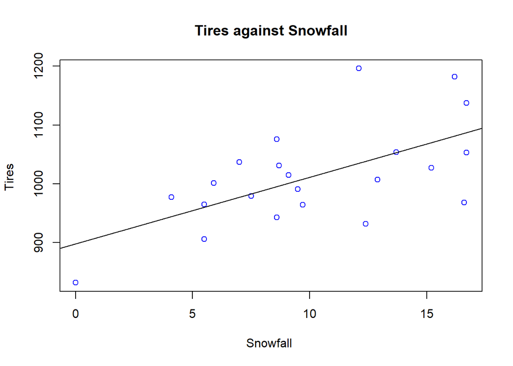

```r
Tires <- read1757$Tires
Snowfall <- read1757$Snowfall
n <- length(Tires)
plot(Snowfall, Tires, col = "blue", main = "Tires against Snowfall", xlab = "Snowfall ", ylab = "Tires ")
abline(lm(Tires ~ Snowfall))
```

```r
n <- length(Tires)
Data.read1757 <- cbind(Snowfall)
linearModelVar <- lm(Tires ~ Snowfall)
cat("# # # # The regression model # # # ","\n")
```

```
## # # # # The regression model # # #
```

```r
print(summary(linearModelVar))
```

```
##
## Call:
## lm(formula = Tires ~ Snowfall)
##
## Residuals:
##      Min       1Q   Median       3Q      Max
## -118.031  -43.702   -1.572   35.734  160.938
##
## Coefficients:
##             Estimate Std. Error t value Pr(>|t|)
## (Intercept)  898.011     35.969  24.967  < 2e-16 ***
## Snowfall      11.327      3.253   3.482  0.00235 **
## ---
## Signif. codes:  0 '***' 0.001 '**' 0.01 '*' 0.05 '.' 0.1 ' ' 1
##
## Residual standard error: 68.63 on 20 degrees of freedom
## Multiple R-squared:  0.3774, Adjusted R-squared:  0.3462
## F-statistic: 12.12 on 1 and 20 DF,  p-value: 0.002353
```

```r
ANOVA_T_lm <- anova(linearModelVar)
cat("# # # # The ANOVA Table # # # ","\n")
```

```
## # # # # The ANOVA Table # # #
```

```r
print(ANOVA_T_lm)
```

```
## Analysis of Variance Table
##
## Response: Tires
##           Df Sum Sq Mean Sq F value   Pr(>F)
## Snowfall   1  57089   57089  12.121 0.002353 **
## Residuals 20  94196    4710
## ---
## Signif. codes:  0 '***' 0.001 '**' 0.01 '*' 0.05 '.' 0.1 ' ' 1
```

Regression model: y = 898.0 + 11.33x, which y means number of snow tires sold weekly, x means the amount of snowfall in inches in each week.

## b.

```r
SE <- standarized_errors_MR(Tires, Data.read1757)[,1]
```

Residual analysis and regression diagnostic analysis:

Non-normality

$H_0$ :Errors are normally distributed

$H_1$:Errors are not normally distributed

```r
Chi_normal_value <- Chi_Square_Normal_Test(SE, 4)
```

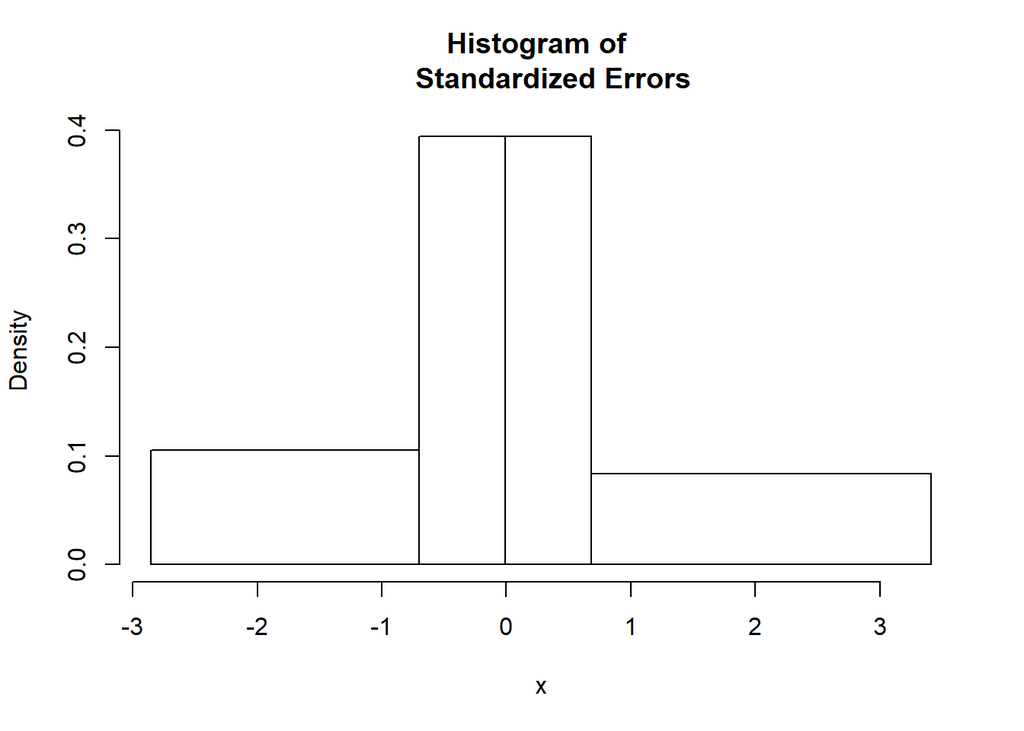

```r
print(Chi_normal_value)
```

```
## X-squared
## 0.6698154
```

since p_value = 0.6698154 > 0.05. We can assume that errors are normally distributed.

Heteroscedasticity and homoscedasticity

$H_0$:Homoscedasticity

$H_1$:Heteroscedasticity

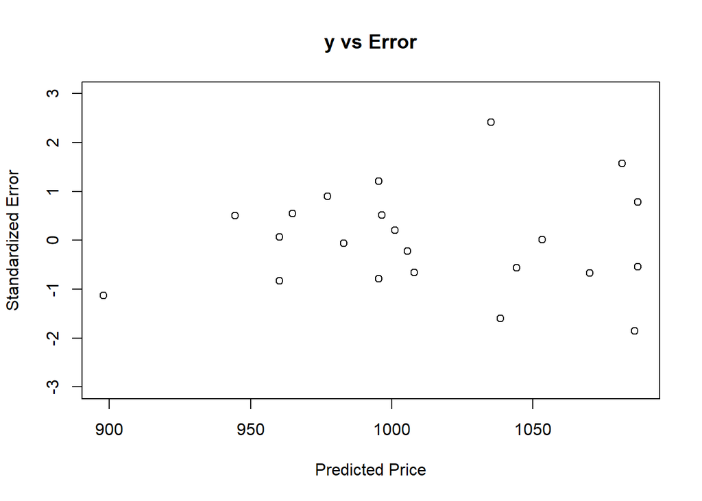

```r
Hetero_plot(Tires,Data.read1757,1)
```

It may have problem of heteroscedasticity

Randomness: Perform run test

H0 : Randomness exist. H1 : Randomness doesn’t exist.

```r
Run_Test_Result <- Run_Test(SE)
```

```
##  [1]  TRUE  TRUE  TRUE  TRUE  TRUE FALSE  TRUE  TRUE  TRUE  TRUE  TRUE
## [12] FALSE FALSE FALSE FALSE FALSE  TRUE FALSE FALSE FALSE FALSE FALSE
```

```r
cat("     ","\n")
```

```r
cat("# # # # The Run Test # # # ","\n")
```

```
## # # # # The Run Test # # #
```

```r
print(Run_Test_Result)
```

```
## [1] 11.000000000 11.000000000  6.000000000 12.000000000  2.288688541
## [6] -2.621588693  0.008752099
```

Since 6 < 7 rejected H0. There is sufficient evidence to infer that the sample is not random.

Autocorrelation: Perform Durbin-Watson test.

Two-tail test for First Order Auto-Correlation: $H_0$: The data are not first-order correlated $H_1$: The data are first-order correlated

```r
cat("# # # # The Durbin Watson Test # # # ","\n")
```

```
## # # # # The Durbin Watson Test # # #
```

```r
DW_test <- Durbin_Watson_Test(SE)
print(DW_test)
```

```
## [1] 1.016998
```

Since d = 1.016998 < dL. We can reject the null hypothesis, so we assume that the data are first-order correlated.

## c.

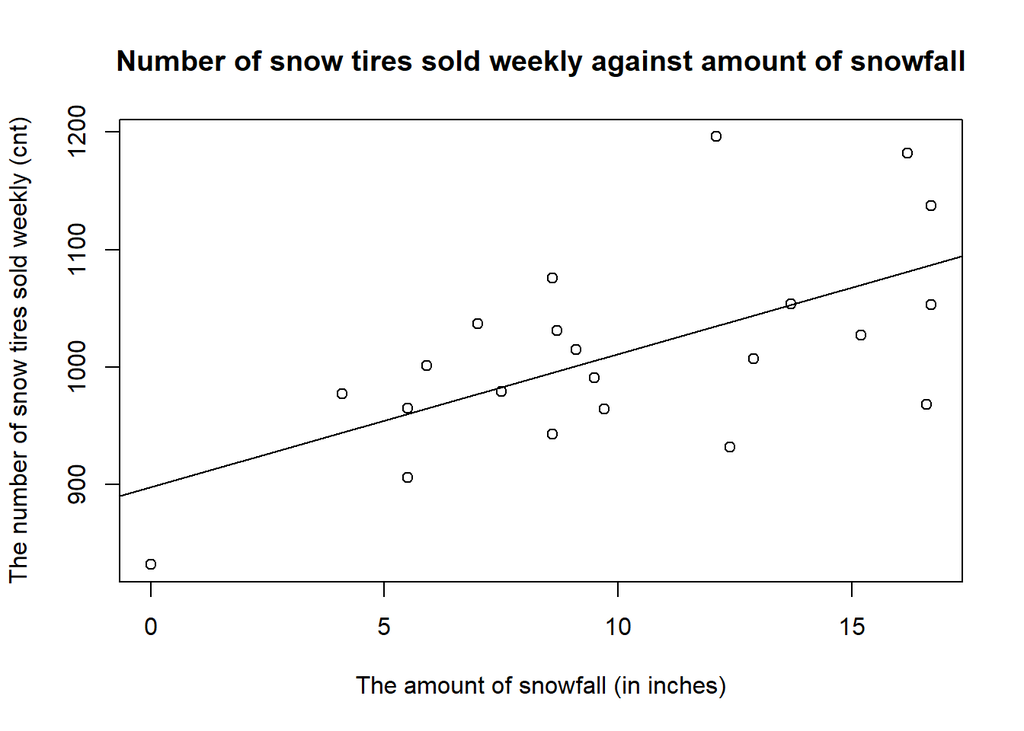

```r
data1757[, 3] = c(0:21)
week = data1757[, 3]
colnames(data1757)[3] <- c("Week")
plot(Tires~Snowfall, data = data1757, main = "Number of snow tires sold weekly against amount of snowfall", xlab = "The amount of snowfall (in inches)", ylab = "The number of snow tires sold weekly (cnt)")
abline(lm(Tires~Snowfall, data = data1757))
```

```r
Data.read1757 <- cbind(Snowfall, week)
linearModelVar <- lm(Tires ~ Data.read1757)
cat("# # # # The regression model # # # ","\n")
```

```
## # # # # The regression model # # #
```

```r
print(summary(linearModelVar))
```

```
##
## Call:
## lm(formula = Tires ~ Data.read1757)
##
## Residuals:
##      Min       1Q   Median       3Q      Max
## -107.756  -34.656   -0.325   29.433   75.230
##
## Coefficients:
##                       Estimate Std. Error t value Pr(>|t|)
## (Intercept)            952.886     28.127  33.878  < 2e-16 ***
## Data.read1757Snowfall   13.885      2.368   5.863  1.2e-05 ***
## Data.read1757week       -7.687      1.679  -4.579 0.000205 ***
## ---
## Signif. codes:  0 '***' 0.001 '**' 0.01 '*' 0.05 '.' 0.1 ' ' 1
##
## Residual standard error: 48.55 on 19 degrees of freedom
## Multiple R-squared:  0.704,  Adjusted R-squared:  0.6728
## F-statistic: 22.59 on 2 and 19 DF,  p-value: 9.498e-06
```

```r
ANOVA_T_lm <- anova(linearModelVar)
cat("# # # # The ANOVA Table # # # ","\n")
```

```
## # # # # The ANOVA Table # # #
```

```r
print(ANOVA_T_lm)
```

```
## Analysis of Variance Table
##
## Response: Tires
##               Df Sum Sq Mean Sq F value    Pr(>F)
## Data.read1757  2 106501   53250  22.592 9.498e-06 ***
## Residuals     19  44785    2357
## ---
## Signif. codes:  0 '***' 0.001 '**' 0.01 '*' 0.05 '.' 0.1 ' ' 1
```

Suppose that the number of Tires Sales weekly (y) is related to the amount of snowfall(in inches) weekly (x1) and time period(x2) The regression line is y_head = 952.886 + 13.885$x_1$ -7.687$x_2$

where y = the number of Tires Sales weekly x1=the amount of snowfall weekly x2=time period.

```r
SE <- standarized_errors_MR(Tires, Data.read1757)[,1]
```

Residual analysis and regression diagnostic analysis:

Non-normality

$H_0$ :Errors are normally distributed

$H_1$:Errors are not normally distributed

```r
Chi_normal_value <- Chi_Square_Normal_Test(SE, 4)
```

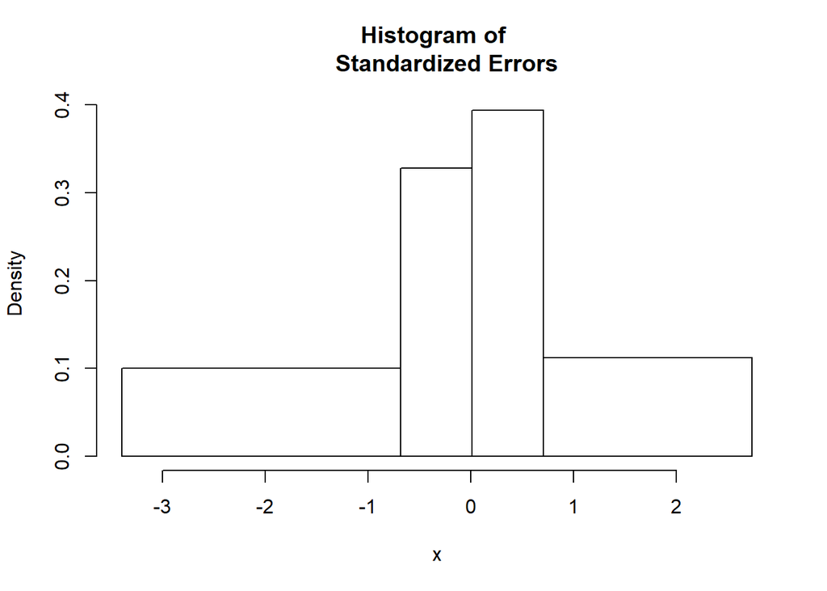

```r
print(Chi_normal_value)
```

```
## X-squared
## 0.6698154
```

since p_value = 0.6698154 > 0.05. We can assume that errors are normally distributed.

Heteroscedasticity and homoscedasticity

$H_0$:Homoscedasticity

$H_1$:Heteroscedasticity

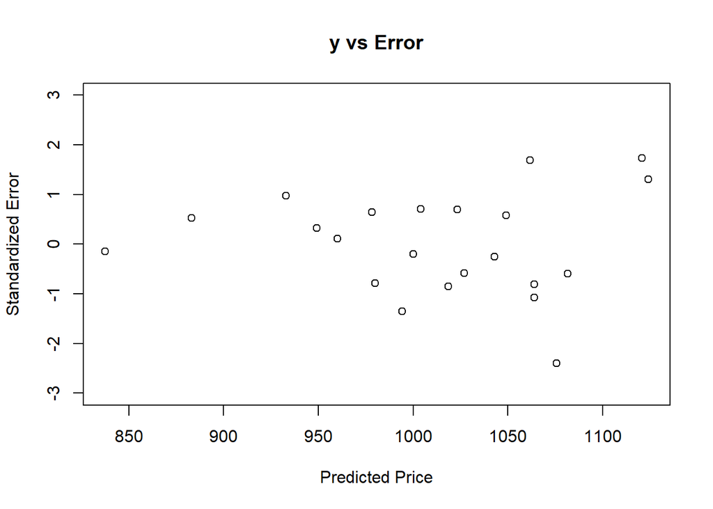

```r
Hetero_plot(Tires,Data.read1757,2)
```

It appears that the variation is constant and the mean is around 0

Randomness: Perform run test

H0 : Randomness exist. H1 : Randomness doesn’t exist.

```r
Run_Test_Result <- Run_Test(SE)
```

```
##  [1]  TRUE FALSE FALSE  TRUE FALSE FALSE  TRUE  TRUE FALSE  TRUE  TRUE
## [12] FALSE FALSE FALSE FALSE FALSE  TRUE FALSE  TRUE  TRUE  TRUE  TRUE
```

```r
cat("     ","\n")
```

```r
cat("# # # # The Run Test # # # ","\n")
```

```
## # # # # The Run Test # # #
```

```r
print(Run_Test_Result)
```

```
## [1] 11.0000000 11.0000000 11.0000000 12.0000000  2.2886885 -0.4369314
## [7]  0.6621611
```

Because 17 > R = 11 > 7, do not rejected H0. We can assume that samples are randomly selected.

Multicollinearity

```r
cor(data1757)
```

```
##               Tires  Snowfall       Week
## Tires     1.0000000 0.6142964 -0.4104371
## Snowfall  0.6142964 1.0000000  0.2359287
## Week     -0.4104371 0.2359287  1.0000000
```

According to the above, there are no independent variables are highly correlated (|r|$\geq$.7); hence there is no multicollinearity problem.

Autocorrelation: Perform Durbin-Watson test.

Two-tail test for First Order Auto-Correlation: $H_0$: The data are not first-order correlated $H_1$: The data are first-order correlated

```r
cat("# # # # The Durbin Watson Test # # # ","\n")
```

```
## # # # # The Durbin Watson Test # # #
```

```r
DW_test <- Durbin_Watson_Test(SE)
print(DW_test)
```

```
## [1] 1.887589
```

Since $d_U$ = 1.54 < d = 1.887579 < 2, hence we can conclude that there is no evidence for first order auto-correlation.

## d.

```r
print(summary(linearModelVar))
```

```
##
## Call:
## lm(formula = Tires ~ Data.read1757)
##
## Residuals:
##      Min       1Q   Median       3Q      Max
## -107.756  -34.656   -0.325   29.433   75.230
##
## Coefficients:
##                       Estimate Std. Error t value Pr(>|t|)
## (Intercept)            952.886     28.127  33.878  < 2e-16 ***
## Data.read1757Snowfall   13.885      2.368   5.863  1.2e-05 ***
## Data.read1757week       -7.687      1.679  -4.579 0.000205 ***
## ---
## Signif. codes:  0 '***' 0.001 '**' 0.01 '*' 0.05 '.' 0.1 ' ' 1
##
## Residual standard error: 48.55 on 19 degrees of freedom
## Multiple R-squared:  0.704,  Adjusted R-squared:  0.6728
## F-statistic: 22.59 on 2 and 19 DF,  p-value: 9.498e-06
```

```r
print(ANOVA_T_lm)
```

```
## Analysis of Variance Table
##
## Response: Tires
##               Df Sum Sq Mean Sq F value    Pr(>F)
## Data.read1757  2 106501   53250  22.592 9.498e-06 ***
## Residuals     19  44785    2357
## ---
## Signif. codes:  0 '***' 0.001 '**' 0.01 '*' 0.05 '.' 0.1 ' ' 1
```

Standard Error of Estimate

```r
cat("Se:", 48.55, "\n")
```

```
## Se: 48.55
```

```r
cat("y_bar:", mean(Tires), "\n")
```

```
## y_bar: 1012.409
```

```r
cat("It seems that Se is small compared to y_bar, hence we can conclude the model fit the data well.")
```

```
## It seems that Se is small compared to y_bar, hence we can conclude the model fit the data well.
```

Coefficient of Multiple Determination, r^2

```r
cat("From the printout, r^2 =  0.704, which conclude that 70.4% of the variation in Sales is explained by this regression line of the two independent variables and 29.6% remains unexplained.
")
```

```
## From the printout, r^2 =  0.704, which conclude that 70.4% of the variation in Sales is explained by this regression line of the two independent variables and 29.6% remains unexplained.
```

```r
cat("r^2_a:", 0.6728, "\n")
```

```
## r^2_a: 0.6728
```

```r
cat("Over-fitting:", 0.704 - 0.6728 > 0.06)
```

```
## Over-fitting: FALSE
```

```r
cat("When adjusted for degrees of freedom with n = 22 and k = 2, r_a^2 =  67.28% is close to70.4% though though 2 independent variables are included in the model, indicating that the model has no problem of over-fitting.")
```

```
## When adjusted for degrees of freedom with n = 22 and k = 2, r_a^2 =  67.28% is close to70.4% though though 2 independent variables are included in the model, indicating that the model has no problem of over-fitting.
```

F Test

$$H_0: \beta_1 = \beta_2 = 0$$
$H_1$: One or both of the parameters is not equal to zero.

```r
cat("Since p-value of F test =  9.498e-06 < 0.05, there is sufficient evidence to reject the null hypothesis in favor of the alternative hypothesis. At least one of the beta_i is not equal to zero. Thus, at least one independent variable is related to y. This regression model is valid.")
```

```
## Since p-value of F test =  9.498e-06 < 0.05, there is sufficient evidence to reject the null hypothesis in favor of the alternative hypothesis. At least one of the beta_i is not equal to zero. Thus, at least one independent variable is related to y. This regression model is valid.
```

## e.

t Test
$$H_0: \beta_i = 0$$
$$H_0: \beta_i \neq 0$$

```r
cat("Since p_value of beta1 = 1.2e-05  < 0.05, p_value of beta2 = 0.000205 < 0.05, with 95% confidence,  we conclude that there is enough evidence to infer that the amount of snowfall and time are linearly related to the number of snow tires sold weekly.")
```

```
## Since p_value of beta1 = 1.2e-05  < 0.05, p_value of beta2 = 0.000205 < 0.05, with 95% confidence,  we conclude that there is enough evidence to infer that the amount of snowfall and time are linearly related to the number of snow tires sold weekly.
```

Interpretation

beta_1 = 13.885, in this model, for each additional amount of snowfall (in inches), the number of snow tires sold weekly increases by 13.885 (assuming the other variables are held constant).

beta_2 = -7.687, in this model, for each additional amount of time (in week), the number of snow tires sold weekly decreases by 7.687 (assuming the other variables are held constant).

# Exercise 18.3

```r
read1803 <- read.csv("D:\\Xr18-03.csv")
data1803 <- data.frame(read1803)
Sales <- read1803$Sales
Space <- read1803$Space
```

## a.

[figure not shown]

```r
plot(data1803$Sales,data1803$Space, col = "blue", main = "Sales against Space", xlab = "Space", ylab = "Sales")
lines(lowess(Sales,Space), col="blue")
abline(lm(Sales~Space, data = data1803))
```

According to the scatter plot,there is quadratic relationship between Sales and Space

$$y = \beta_0 + \beta_1 x + \beta_2 x^2 + \epsilon$$
y = the number of boxes of detergent sold (cnt). x = shelf space (in inches). ε = error variable.

## b.

```r
Space_T = Space - mean(Space)
Space_sq = Space_T^2
Data.Sales_Space = cbind(Space_T,Space_sq)
linearModelVar1803 <- lm(Sales ~ Data.Sales_Space)
n1803 <- length(Sales)
cat("# # # # The regression model # # # ","\n")
```

```
## # # # # The regression model # # #
```

```r
print(summary(linearModelVar1803))
```

```
##
## Call:
## lm(formula = Sales ~ Data.Sales_Space)
##
## Residuals:
##     Min      1Q  Median      3Q     Max
## -62.808 -25.063   1.614  26.806 115.550
##
## Coefficients:
##                          Estimate Std. Error t value Pr(>|t|)
## (Intercept)              301.8077    12.3608  24.417   <2e-16 ***
## Data.Sales_SpaceSpace_T    1.1438     1.1412   1.002   0.3271
## Data.Sales_SpaceSpace_sq  -0.6655     0.1774  -3.752   0.0011 **
## ---
## Signif. codes:  0 '***' 0.001 '**' 0.01 '*' 0.05 '.' 0.1 ' ' 1
##
## Residual standard error: 41.15 on 22 degrees of freedom
## Multiple R-squared:  0.4068, Adjusted R-squared:  0.3528
## F-statistic: 7.542 on 2 and 22 DF,  p-value: 0.003203
```

```r
ANOVA_T_lm1803 <- anova(linearModelVar1803)
cat("# # # # The ANOVA Table # # # ","\n")
```

```
## # # # # The ANOVA Table # # #
```

```r
print(ANOVA_T_lm1803)
```

```
## Analysis of Variance Table
##
## Response: Sales
##                  Df Sum Sq Mean Sq F value   Pr(>F)
## Data.Sales_Space  2  25540 12769.8  7.5422 0.003203 **
## Residuals        22  37248  1693.1
## ---
## Signif. codes:  0 '***' 0.001 '**' 0.01 '*' 0.05 '.' 0.1 ' ' 1
```

The regression line is y_head = 301.8077+1.1438x−0.6655x^2, where y denotes the number of boxes of detergent sold, x denotes shelf space (in inches).

## b.

Standard Error of Estimate

```r
cat("Se:", 41.15, "\n")
```

```
## Se: 41.15
```

```r
cat("y_bar:", mean(Sales), "\n")
```

```
## y_bar: 267.2
```

```r
cat("It seems that Se is small compared to y_bar, hence we can conclude the model fit the data well.")
```

```
## It seems that Se is small compared to y_bar, hence we can conclude the model fit the data well.
```

Coefficient of Multiple Determination, r^2

```r
cat("From the printout, r^2 =  0.4068, which conclude that 40.68% of the variation in Sales is explained by this regression line  and 59.32% remains unexplained.
")
```

```
## From the printout, r^2 =  0.4068, which conclude that 40.68% of the variation in Sales is explained by this regression line  and 59.32% remains unexplained.
```

```r
cat("r^2_a:", 0.3528, "\n")
```

```
## r^2_a: 0.3528
```

```r
cat("Over-fitting:", 0.4068 - 0.3528 > 0.06)
```

```
## Over-fitting: FALSE
```

```r
cat("When adjusted for degrees of freedom with n = 25 and k = 2, r_a^2 =  35.28% is close to 40.68% though though 2 independent variables are included in the model, indicating that the model has no problem of over-fitting.")
```

```
## When adjusted for degrees of freedom with n = 25 and k = 2, r_a^2 =  35.28% is close to 40.68% though though 2 independent variables are included in the model, indicating that the model has no problem of over-fitting.
```

F Test

$$H_0: \beta_1 = \beta_2 = 0$$
$H_1$: One or both of the parameters is not equal to zero.

```r
cat("Since p-value of F test =  0.003203 < 0.05, there is sufficient evidence to reject the null hypothesis in favor of the alternative hypothesis. At least one of the beta_i is not equal to zero. Thus, at least one independent variable is related to y. This regression model is valid.")
```

```
## Since p-value of F test =  0.003203 < 0.05, there is sufficient evidence to reject the null hypothesis in favor of the alternative hypothesis. At least one of the beta_i is not equal to zero. Thus, at least one independent variable is related to y. This regression model is valid.
```

t Test
$$H_0: \beta_i = 0$$
$$H_0: \beta_i \neq 0$$

```r
cat("Since p_value of beta_2 = 0.0011  < 0.05, with 95% confidence,  we conclude that there is enough evidence to infer that shelf space (in inches) is quadratically related to the number of boxes of detergent sold.")
```

```
## Since p_value of beta_2 = 0.0011  < 0.05, with 95% confidence,  we conclude that there is enough evidence to infer that shelf space (in inches) is quadratically related to the number of boxes of detergent sold.
```

# Exercise 18.9

```r
read1809 <- read.csv("D:\\Xr18-09.csv")
data1809 <- data.frame(read1809)
Goal_diff <- read1809$Goal_diff
Faceoff <- read1809$Faceoff
PM_diff <- read1809$PM_diff
```

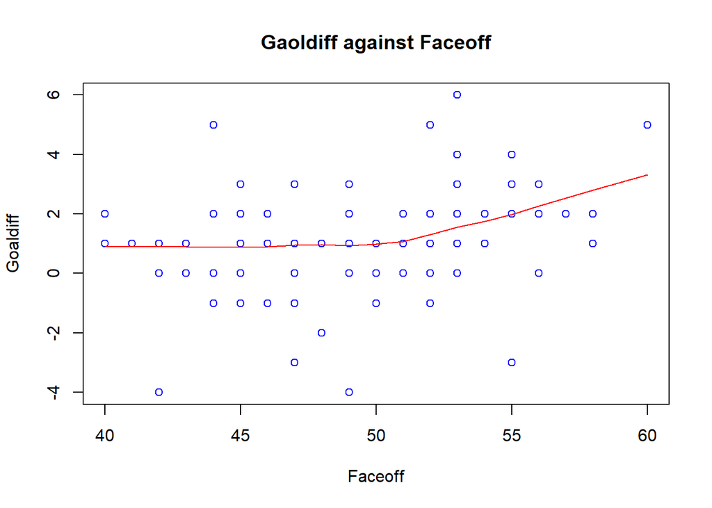

```r
plot(Faceoff, `Goal_diff`, col = "blue", main = "Gaoldiff against Faceoff", xlab = "Faceoff", ylab = "Goaldiff")
lines(lowess(Faceoff, `Goal_diff`), col="red")
```

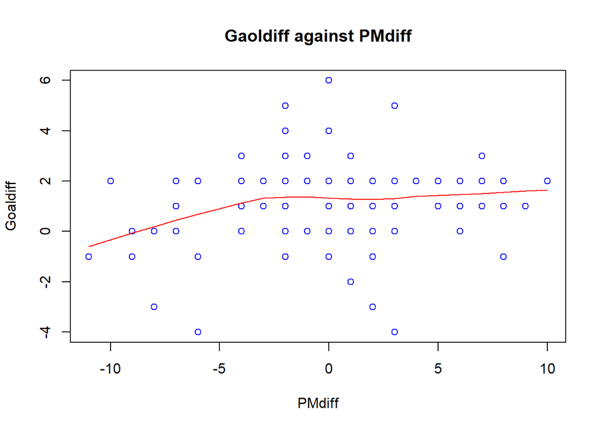

```r
plot(`PM_diff`, `Goal_diff`, col = "blue", main = "Gaoldiff against PMdiff", xlab = "PMdiff", ylab = "Goaldiff")
lines(lowess(`PM_diff`, `Goal_diff`), col="red")
```

```r
Faceoff_T = Faceoff
PM_diff_T = PM_diff
Face_Pm = Faceoff_T * PM_diff_T
Data.Goal_diff = cbind(Faceoff_T,PM_diff_T,Face_Pm)
linearModelVar1809 <- lm(Goal_diff ~ Data.Goal_diff)
n1809 <- length(Goal_diff)
cat("# # # # The regression model # # # ","\n")
```

```
## # # # # The regression model # # #
```

```r
print(summary(linearModelVar1809))
```

```
##
## Call:
## lm(formula = Goal_diff ~ Data.Goal_diff)
##
## Residuals:
##     Min      1Q  Median      3Q     Max
## -4.9757 -0.6645  0.0093  0.7985  4.4354
##
## Coefficients:
##                           Estimate Std. Error t value Pr(>|t|)
## (Intercept)             -4.8565893  1.8282415  -2.656  0.00925 **
## Data.Goal_diffFaceoff_T  0.1211542  0.0366407   3.307  0.00133 **
## Data.Goal_diffPM_diff_T  0.1350127  0.3993079   0.338  0.73601
## Data.Goal_diffFace_Pm   -0.0009202  0.0079945  -0.115  0.90860
## ---
## Signif. codes:  0 '***' 0.001 '**' 0.01 '*' 0.05 '.' 0.1 ' ' 1
##
## Residual standard error: 1.585 on 96 degrees of freedom
## Multiple R-squared:  0.1435, Adjusted R-squared:  0.1167
## F-statistic:  5.36 on 3 and 96 DF,  p-value: 0.001866
```

```r
ANOVA_T_lm1809 <- anova(linearModelVar1809)
cat("# # # # The ANOVA Table # # # ","\n")
```

```
## # # # # The ANOVA Table # # #
```

```r
print(ANOVA_T_lm1809)
```

```
## Analysis of Variance Table
##
## Response: Goal_diff
##                Df  Sum Sq Mean Sq F value   Pr(>F)
## Data.Goal_diff  3  40.378 13.4593    5.36 0.001866 **
## Residuals      96 241.062  2.5111
## ---
## Signif. codes:  0 '***' 0.001 '**' 0.01 '*' 0.05 '.' 0.1 ' ' 1
```